# Przypadek II

Przykłady modeli LR do rozdziału *Iloraz wiarygodności jako rekomendowane narzędzie weryfikacji hipotezy o wspólnym pochodzeniu dowodów rzeczowych

## Ocena jakości modeli LR

Efektywność modeli LR należy ocenić na podstawie wartości LR obliczonych dla wielu par próbek dowodowych i porównawczych, o których wiemy, iż pochodzą lub nie z tego samego źródła. W tym celu utworzono specjalny skrypt obliczenowy R LR_comparison_research_code.R, dostępny w folderze II. Egzekucja (wywołanie) tego kodu wymaga kilku minut w zależności od mocy obliczeniowej komputera.

Poniżej kod ten rozbity jest na kilka istotnych fragmentów. Kod ten w istocie skomponowany jest z fragmentów kodu z poprzednich przykładów (Przypadek I). Kluczowym elementem jest ponownie podwójna pętla, dzięki której obliczenia dokonywane są dla każdej możliwej pary próbek z bazy danych, z których jedna stanowi próbkę dowodową, a druga porównawczą. Ze względu na obecność pętli, obliczenia, które nie są zależne od tego, które próbki są aktualnie porównywane, mogą pojawić się przed pętlą. Stąd też kolejność komend nie zawsze idealnie odpowiada tej z poprzednich przykładów. Ponadto modyfikacja dotyczy także zewnętrznej pętli, przebiegającej wszystkie submodele (v), jakie rozpatrujemy. Ma to znaczenie w modelach naiwnych oraz definiowanych np. na podstawie dekompozycji modeli graficznych. Istotną zmianą jest modyfikacja zawartości bazy danych dla każdego porównania zgodnie z procedurą opisaną w podrozdziale *Konstrukcja zbiorów uczących i testowych->Podział na zbiory uczące i testowe, gdy m>>p*.

Ładowanie pakietów oraz funkcji:

```r
source("../BW_function.R")
source("../LR_Nor_comparison_function.R")
source("../LR_KDE_comparison_function.R")

if (!require("mvtnorm")) install.packages("mvtnorm")
```

Ładowanie danych z pliku zawierającego bazę danych (population). Dodatkowo wprowadzamy zmienną data.analysed, która będzie przechowywać oryginalną bazę danych, podczas gdy zmienna population zmienia się w zależności od porównywanych próbek.

```r
population = read.table("../demo_glass_database.txt", header = TRUE)
data.analysed = population
```

Liczbę próbek zgromadzonych w bazie danych (M) oraz ich numery (items), a także liczbę pomiarów dla próbek z bazy danych (n) można uzyskać wpisując:

```r
items = unique(population$Item)
M = length(unique(population$Item))
n = length(unique(population$Piece))

print(paste("liczba próbek w bazie danych = ",M));print(paste("liczba pomiarów = ",n))
```

```
## [1] "liczba próbek w bazie danych =  50"
```

```
## [1] "liczba pomiarów =  12"
```

Załóżmy, że nasz model LR będzie modelem, w którym finalną wartość LR uzyskuje się przez podzielenie dwóch submodeli - pierwszego bazującego na trzech zmiennych opisujących zawartość sodu, wapnia i krzemu tj. logNaO, logCaO, logSiO, i drugiego bazującego na zawartości magnezu (logMgO), LR=LR<sub>NaSiCa</sub>/LR<sub>Mg</sub>. Wymiarowość każdego z submodeli będzie przechowywana w zmiennej p (tutaj p=3 oraz 1). W zmiennej variables.list przechowuje się listę zmiennych. Każdy element listy oznacza jeden submodel. W tym przypadku mamy jeden submodel trójwymiarowy oraz jeden submodel jednowymiarowy. W zmiennej ND należy podać N, gdy wynik LR dla submodelu powinien znaleźć się w liczniku lub D, gdy w mianowniku finalnego wyrażenia na LR. Ma to znaczenie w przypadku modeli definiowanych np. na podstawie dekompozycji modeli graficznych. Ponieważ finalna wartość LR jest stosunkiem dwóch wartości LR uzyskanych dla submodeli opartych na zmiennych logNaO, logCaO, logSiO pierwszy oraz logMgO drugi, wówczas zmienna ND jest wektorem o elementach N i D , tj. ND = c(“N”,“D”). Zmienna variable.name przechowuje nazwę modelu, jaką mu chcemy nadać. Będzie ona identyfikowała model w zapisanych plikach wynikowych.

```r
variables.list = list(c("logSiO","logNaO","logCaO"),c("logMgO"))
ND = c("N","D")
variable.name = "NaSiCaMg"
```

Wynikowe macierze (w przypadku założenia rozkładu normalnego output.matrix.Nor i output.matrix.KDE, gdy rozkład modelujemy przez KDE) będą zawierać wszystkie wartości LR dla każdej z par próbek dowodowych i porównawczych, gdzie rzędy odpowiadają próbkom dowodowym, a kolumny porównawczym. Macierze te zawierają więc liczbę rzędów i kolumn równą liczbie próbek w bazie danych:

```r
output.matrix.Nor = output.matrix.KDE = matrix(1,ncol = M, nrow = M,dimnames=list(c(as.character(unique(population$Name))),c( as.character(unique(population$Name)))))
```

W kolejnym fragmencie kodu pierwsza pętla przebiega po zmiennej v, czyli wszystkich submodelach, jakie rozpatrujemy (tutaj dwa submodele).

Następnie kolejne dwie pętle przebiegają po każdej próbce z bazy danych stanowiącej w danym porównaniu próbkę dowodową (i) oraz każdej próbce z bazy danych stanowiącej próbkę porównawczą (j), by obliczyć LR dla każdej ich pary. Numer próbki porównawczej jest równy lub większy od numeru próbki dowodowej, by uniknąć podwójnych porównań dających ten sam wynik. To znaczy, że porównanie próbki 10 z 15 daje ten sam rezultat, co 15 z 10. Kolejnym etapem jest utworzenie próbek y.1 i y.2 oraz population zgodnie z założoną procedurą tworzenia zbiorów testowych i uczących opisaną w *Konstrukcja zbiorów uczących i testowych->Podział na zbiory uczące i testowe, gdy m>>p*. Rozpatrywane są przypadki, gdy porównujemy próbki pochodzące z tego samego źrodła (H<sub>1</sub>) lub nie pochodzące z jednego źródła (H<sub>2</sub>). W poniższym fragmencie kodu zbiory uczące i testowe oznaczono odpowiednimi literami za pomocą komentarzy ## zgodnie z notacją zamieszczoną w podrozdziale *Konstrukcja zbiorów uczących i testowych->Podział na zbiory uczące i testowe, gdy m>>p*. Gdy H<sub>1</sub> jest prawdziwa, każda z próbek dzielona jest na dwie y.1 i y.2, gdzie y.1 zawiera pomiary o numeryach 1, 3, 5, 7, 9, 11, a y.2 pozostałe. Ze względu na nieustannie zmieniający się skład bazy danych w każdym porównaniu, konieczne jest obliczenie aktualnej liczby próbek, m. Kolejno liczymy macierze $\mathbf{W}$ i $\mathbf{B}$, średnią dla wszystkich próbek z bazy danych (x.mean ($\mathbf{\bar{x}}$)) oraz parametr wygładzający h. Podobnie, jak w poprzednich przykładach obliczamy liczbę pomiarów dla próbek y.1 i y.2 (k.1 ($k_1$), k.2 ($k_2$)), ich średnie (y.mean.1 ($\mathbf{\bar{y}}_1$), y.mean.2 ($\mathbf{\bar{y}}_2$), y.star ($\mathbf{\bar{y}}^{*}$)).

Na podstawie zgromadzonych danych obliczamy wartości LR zakładając rozkład normalny średnich dla próbek w bazie danych (LR.Nor) lub modelując go za pomocą KDE (LR.KDE). Każda obliczona wartość zostaje wpisana do macierzy wynikowych (output.matrix.Nor i output.matrix.KDE). Ponieważ rozpatrujemy model składający się z wielu submodeli, dających wartości LR, z których jeden pojawia się w liczniku, a drugi w mianowniku finalnego wyrażenia na LR, pierwsza generowana wartość LR w zewnętrznej pętli staje się czynnikiem mnożącym, a druga dzielnikiem zgodnie z zapisem w zmiennej ND.

```r
for (v in 1:length(variables.list))
{
  variables = variables.list[[v]]
  variables = which(colnames(population) %in% variables)
  p = length(variables)

  for (i in 1:M)
  {
    for (j in i:M)
    {
      if (i == j)
      {
        y.1.2 = data.analysed[which(data.analysed$Item == items[i]),]
        y.1 = data.frame(y.1.2[c(1,3,5,7,9,11),])
        y.2 = data.frame(y.1.2[c(2,4,6,8,10,12),])

        population = data.analysed[which(data.analysed$Item != items[i]),] ##A, gdy H1 jest prawdziwa
        m = length(unique(population$Item))
      }
      else
      {
        y.1 = data.frame(data.analysed[which(data.analysed$Item == items[i]),])
        y.2 = data.frame(data.analysed[which(data.analysed$Item == items[j]),])

        population = data.analysed[which(!data.analysed$Item %in% c(items[i],items[j])),] ##A, gdy H2 jest prawdziwa
        m = length(unique(population$Item))
      }

      results.BW = BW(population, variables, n, m)
      W = results.BW$W
      B = results.BW$B

      ifelse(p>1,x.mean<-colMeans(population[,variables]),x.mean<-mean(population[,variables]))

      h = (4/(m*(2*p+1)))^(1/(p+4))

      k.1 = length(y.1$Item)
      k.2 = length(y.2$Item)

      y.mean.1 = matrix(apply(as.matrix(y.1[,variables]), 2, mean), nrow = 1)
      y.mean.2 = matrix(apply(as.matrix(y.2[,variables]), 2, mean), nrow = 1)
      y.star = (k.1*y.mean.1+k.2*y.mean.2)/(k.1+k.2)

      results.LR.Nor = LR.Nor.function(y.mean.1, y.mean.2, y.star, x.mean, W, B, k.1, k.2)
      LR.Nor = results.LR.Nor$LR.Nor

      results.LR.KDE= LR.KDE.function(y.mean.1, y.mean.2, y.star, W, B, h, population, variables, p, k.1, k.2)
      LR.KDE = results.LR.KDE$LR.KDE

      if (ND[v] == "N")
      {
        output.matrix.Nor[i,j] = output.matrix.Nor[i,j] * LR.Nor
        output.matrix.KDE[i,j] = output.matrix.KDE[i,j] * LR.KDE
      } else
      {
        output.matrix.Nor[i,j] = output.matrix.Nor[i,j] * 1/LR.Nor
        output.matrix.KDE[i,j] = output.matrix.KDE[i,j] * 1/LR.KDE
      }
    }
  }
}
```

Uzyskane macierze wynikowe (z wartościami LR zaokrąglonymi do 4 miejsc znaczących) można zapisać do plików, które zostaną utworzone przez program i zapisane w folderze, w którym pracujemy. Nazwy plików będą identyfikowane poprzez nadaną nazwę modelu w zmiennej variable.name, NaSiCaMg_comparison_research_Nor.txt oraz NaSiCaMg_comparison_research_KDE.txt.

```r
write.table(signif(output.matrix.Nor, digits = 4), file = paste(variable.name,"_comparison_research_Nor.txt", sep=""), quote = FALSE, sep = "\t")
write.table(signif(output.matrix.KDE, digits = 4), file = paste(variable.name,"_comparison_research_KDE.txt", sep=""), quote = FALSE, sep = "\t")
```

Uzyskane wyniki LR służą do ustalenia efektywności modeli LR na podstawie poziomów wskazań fałszywie pozytywnych i fałszywie negatywnych oraz diagramów empiryczej entropii krzyżowej, ECE (podrozdział *Walidacja - ocena poprawności działania modeli LR*). Wartości LR dla porównań, gdy H<sub>1</sub> jest prawdziwa (LR.H1.Nor i LR.H1.KDE) znajdują się na diagonali macierzy output.matrix.Nor i output.matrix.KDE. Górny trójkąt macierzy mieści natomiast wartości LR uzyskane, gdy H<sub>2</sub> jest prawdziwa (LR.H2.Nor i LR.H2.KDE). Liczba odpowiedzi fałszywie pozytywnych (fp.Nor i fp.KDE) stanowi procent wszystkich wartości LR powyżej jedności spośród tych obliczonych, gdy H<sub>2</sub> jest prawdziwa. Liczba odpowiedzi fałszywie negatywnych (fn.Nor i fn.KDE) stanowi procent wszystkich wartości LR poniżej jedności spośród tych obliczonych, gdy H<sub>1</sub> jest prawdziwa. Wartości te podane są w macierzy wynikowej error_rates, gdzie w rzędach kolejno mieszczą się wartości fp.Nor, fp.KDE, fn.Nor, fn.KDE. Macierz ta zapisana zostanie do pliku, utworzonego przez program i zapisanego w folderze, w którym pracujemy. Nazwa pliku będzie identyfikowana poprzez nadaną nazwę modelu w zmiennej variable.name, NaSiCaMg_comparison_research_error_rate.txt.

```r
fp.all = M*(M-1)/2
LR.H2.Nor = output.matrix.Nor[upper.tri(output.matrix.Nor, diag = FALSE)]
LR.H2.KDE = output.matrix.KDE[upper.tri(output.matrix.KDE, diag = FALSE)]
LR.H1.Nor = diag(output.matrix.Nor)
LR.H1.KDE = diag(output.matrix.KDE)
fp.Nor = length(which(LR.H2.Nor>1))/fp.all*100
fp.KDE = length(which(LR.H2.KDE>1))/fp.all*100
fn.Nor = length(which(LR.H1.Nor<1))/M*100
fn.KDE = length(which(LR.H1.KDE<1))/M*100

error_rates = matrix(0, nrow = 4, ncol = 1,dimnames=list(c("fp_Nor", "fp_KDE", "fn_Nor", "fn_KDE"),c(variable.name)))
error_rates[1,1] = fp.Nor
error_rates[2,1] = fp.KDE
error_rates[3,1] = fn.Nor
error_rates[4,1] = fn.KDE
write.table(signif(error_rates, digits = 3), file=paste(variable.name,"_comparison_research_error_rate.txt",sep=""), quote = FALSE, sep = "\t")

print(error_rates)
```

```
##        NaSiCaMg
## fp_Nor 13.55102
## fp_KDE 13.46939
## fn_Nor  6.00000
## fn_KDE  6.00000
```

Diagramy ECE (podrozdział *Walidacja - ocena poprawności działania modeli LR*) można narysować na podstawie poniższego fragmentu kodu wykorzystującego funkcję ECE_plot() zapisaną w osobnym pliku ECE_function.R. Powstałe grafiki zapisane zostaną do plików .png, utworzonych przez program i zapisanych w folderze, w którym pracujemy. Nazwy plików będą identyfikowane poprzez nadaną nazwę modelu w zmiennej variable.name, NaSiCaMg_Nor_ECE.png, NaSiCaMg_KDE_ECE.png.

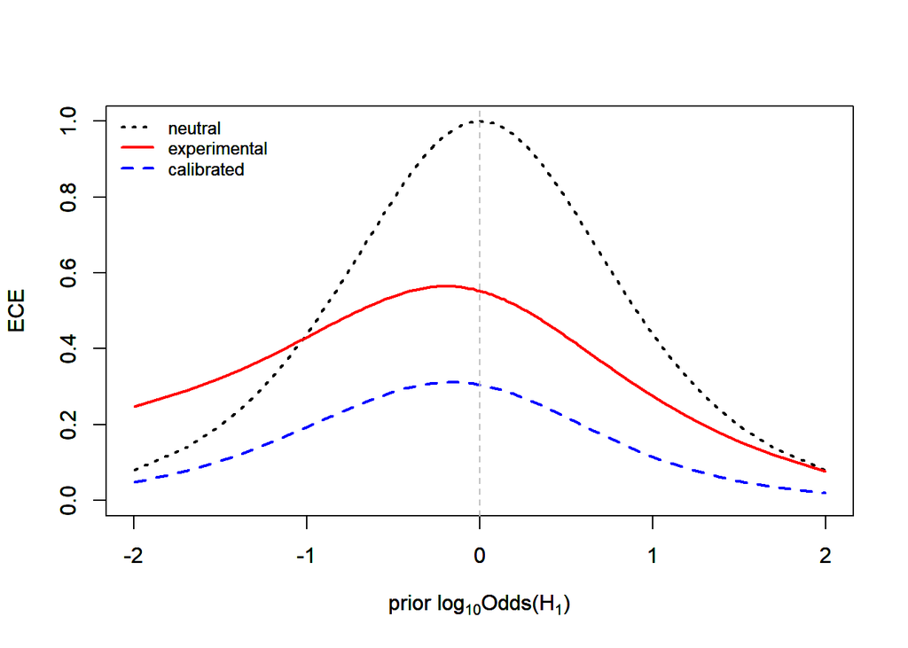

```r
source("../ECE_function.R")
ECE = ECE_plot(LR.H1.Nor,LR.H2.Nor)
```

```r
dev.copy(png, paste(variable.name,"_Nor_ECE.png", sep=""))
```

```r
dev.off()
```

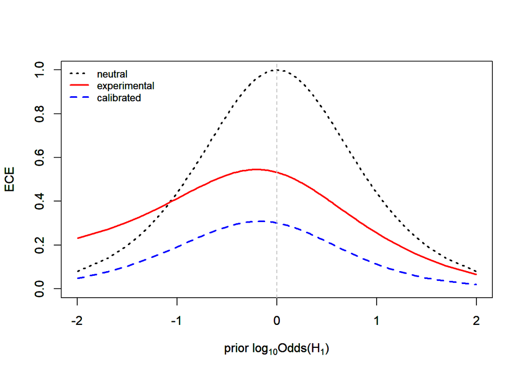

```r
ECE = ECE_plot(LR.H1.KDE,LR.H2.KDE)
```

```r
dev.copy(png, paste(variable.name,"_KDE_ECE.png", sep=""))
```

```r
dev.off()
```

**INTERPRETACJA: Poziomy odpowiedzi fałszywie pozytywnych (ok. 13%) oraz fałszywie negatywnych (6%) są akceptowalne. Diagramy ECE również wskazują, że analizowany model LR z reguły wspiera prawidłowe hipotezy, a wsparcie to jest znaczące. Wsparcie dla błędnych hipotez pojawiające się sporadycznie nie jest duże. Zakładając równe wartości prawodpodobieństw a priori (tzn. $prior$ $log_{10}Odds(H_1)$) zyskujemy około 40% informacji po zastosowaniu tego modelu LR w porównaniu do modelu neutralnego (LR=1). Diagram ECE pokazuje też, iż wiarygodność modelu w zakresie niskich $prior$ $log_{10}Odds(H_1)$ jest mniejsza, ponieważ krzywa eksperymentalna pojawia się ponad krzywą dla modelu neutralnego, sugerując pogorszenie stosowanego modelu w stosunku do tego ostatniego w zakresie niskich $prior$ $log_{10}Odds(H_1)$. Ponadto kluczowym staje się też pytanie, który z modeli jest lepszy, ten oparty o rozkład normalny, czy KDE? W tym przypadku oba modele dają porównywalne rezultaty. W razie rozbieżności bardziej adekwatny powinien okazać się model bazujący na KDE, ponieważ rozkład modelowany empirycznie jest bliższy rzeczywistości niż założony rozkład normalny. Innym sposobem jest też wykorzystanie testów istotości, które pozwalają na ustalenie, czy dane użyte do modelu mogą pochodzić z rozkładu normalnego.**